# Building a CNN

In this part, you will build and evaluate a custom CNN model for image classification. You will work with a multi-class dataset to practice key aspects of building, training, and evaluating CNNs in PyTorch. Expected accuracy on the test dataset: > 85%. The dataset consists of 36 categories and 2800 examples per category (100,800 total). Each image is 28x28.

## Step 1: Data preparation

1. Load the dataset using `ImageFolder` and prepare the dataloader.

```python
import os
from torchvision import datasets, transforms
from torch.utils.data import DataLoader

# Path to the unzipped dataset folder
data_dir = '/content/cnn_part_1_dataset/cnn_dataset'

# Define the transformer to convert to tensor
transform = transforms.Compose([
    transforms.ToTensor(),
])

# Load the dataset using ImageFolder
dataset = datasets.ImageFolder(root=data_dir, transform=transform)

# Prepare the dataloader
batch_size = 64
dataloader = DataLoader(dataset, batch_size=batch_size, shuffle=True)
```

2. Analyze the dataset: brief description, key features, and statistics.

```python
import numpy as np

# Number of samples
num_samples = len(dataset)

# Number of classes
num_classes = len(dataset.classes)

# Class names
class_names = dataset.classes

# Shape of am image
sample_img, sample_label = dataset[0]
img_shape = sample_img.shape

# stack all image tensors into a single tensor
all_imgs = torch.stack([img for img, _ in dataset])

# Compute statistics across all pixels
mean = all_imgs.mean().item()
std = all_imgs.std().item()
min_pixel = all_imgs.min().item()
max_pixel = all_imgs.max().item()

print(f"Total samples: {num_samples}")
print(f"Number of classes: {num_classes}")
print(f"Image shape (C, H, W): {img_shape}")
print(f"Labels example: {dataset.classes[:]}")
print(f"Mean pixel value: {mean:.4f}")
print(f"Standard deviation: {std:.4f}")
print(f"Min pixel value: {min_pixel}")
print(f"Max pixel value: {max_pixel}")
```

```
Total samples: 100800
Number of classes: 36
Image shape (C, H, W): torch.Size([3, 28, 28])
Labels example: ['0', '1', '2', '3', '4', '5', '6', '7', '8', '9', 'A', 'B', 'C', 'D', 'E', 'F', 'G', 'H', 'I', 'J', 'K', 'L', 'M', 'N', 'O', 'P', 'Q', 'R', 'S', 'T', 'U', 'V', 'W', 'X', 'Y', 'Z']
Mean pixel value: 0.1758
Standard deviation: 0.3337
Min pixel value: 0.0
Max pixel value: 1.0
```

- This dataset consists of a total of 100,800 images, distributed across 36 categories: digits (0–9) and uppercase English letters (A–Z).
- Each image has a shape of [3, 28, 28], meaning 3 channels (RGB) and a resolution of 28×28 pixels.
- Although the images appear grayscale, they are stored in RGB format, where each channel has identical values, making them visually black and white but technically 3 channel.
- The pixel values range from 0 to 1, with a mean of 0.1758 and standard deviation of 0.3337.
- This indicates that most of the pixels are dark as expected, because the characters occupy a small bright region while the background remains dark.
3. Create three different visualizations to explore the dataset.
- **Display a grid of sample images from each class**

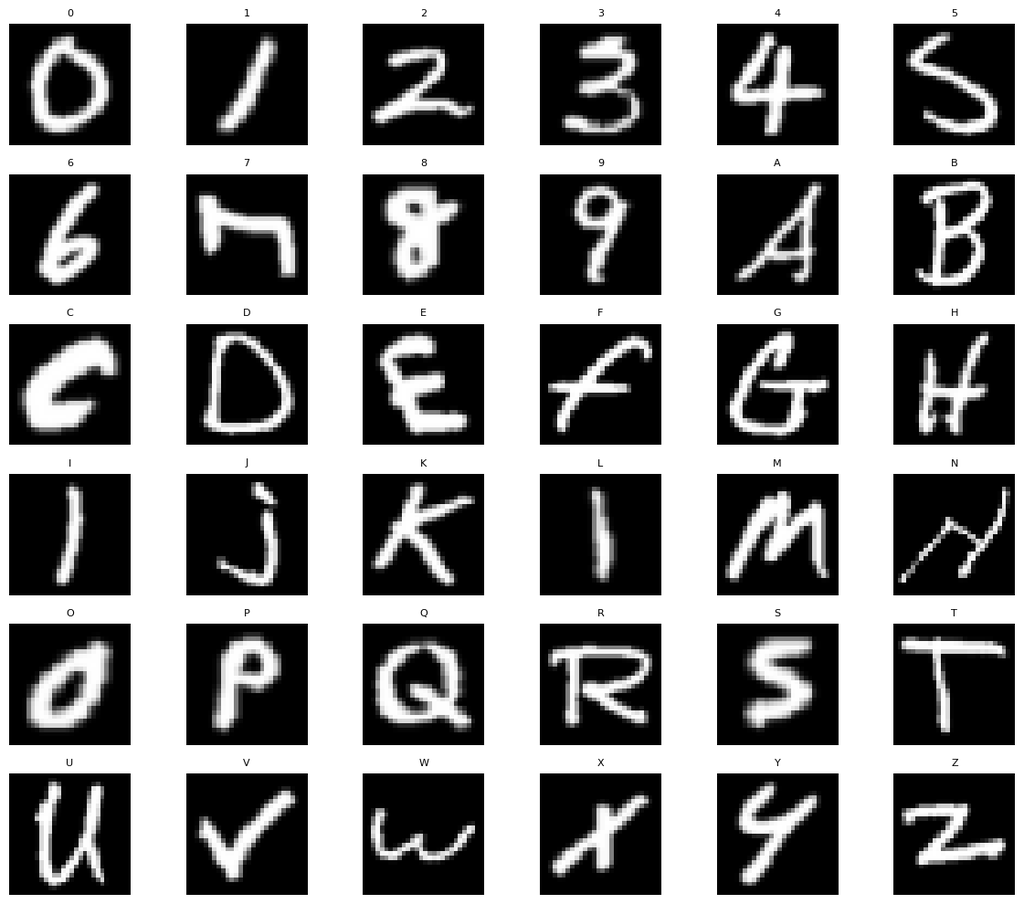

```python
import matplotlib.pyplot as plt

seen_classes = set()
samples = []

for img, label in dataset:
    if label not in seen_classes:
        samples.append((img, dataset.classes[label]))
        seen_classes.add(label)
    if len(samples) == len(dataset.classes):
        break

fig, axes = plt.subplots(6, 6, figsize=(12, 10))
for ax, (img, label) in zip(axes.flatten(), samples):
    ax.imshow(img.permute(1, 2, 0).squeeze(), cmap='gray')
    ax.set_title(label, fontsize=8)
    ax.axis('off')

plt.tight_layout()
plt.show()
```

**Description:** The image grid displays one representative sample from each of the 36 classes in the dataset. These include digits (0–9) and uppercase English letters (A–Z), all rendered as grayscale characters on a 28×28 pixel canvas. This visualization helps confirm the class diversity, visual clarity, and class balance in the dataset.

- **Bar chart showing the number of images per class**

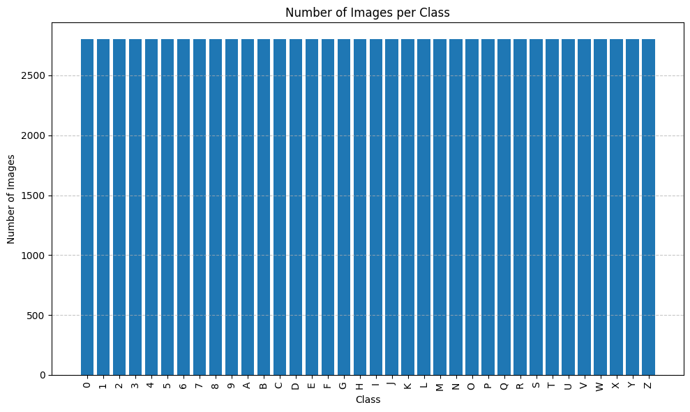

```python
import matplotlib.pyplot as plt
from collections import Counter

# Count labels
label_counts = Counter(lable for _, lable in dataset)
class_names = dataset.classes
class_indices = list(range(len(class_names)))
counts = [label_counts[i] for i in class_indices]

# Create a bar chart
plt.figure(figsize=(10, 6))
plt.bar(class_names, counts)
plt.xlabel('Class')
plt.ylabel('Number of Images')
plt.title('Number of Images per Class')
plt.xticks(rotation=90)
plt.grid(axis='y', linestyle='--', alpha=0.7)
plt.tight_layout()
plt.show()
```

**Description:** The bar chart displays the number of images in each of the 36 classes. As shown, all classes contain exactly 2,800 images, confirming that the dataset is perfectly balanced. This balanced distribution ensures that the model will not be biased toward any specific class during training, which is crucial for achieving fair and consistent classification performance.

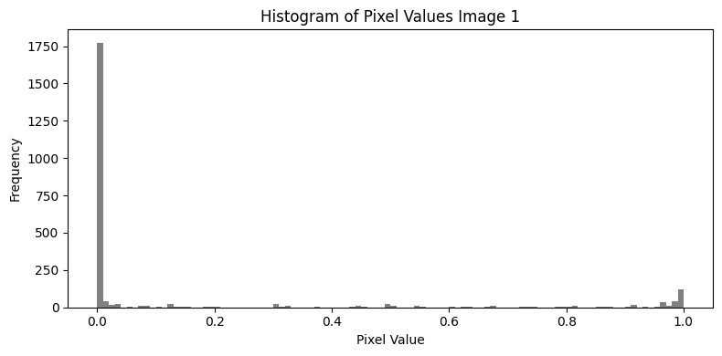

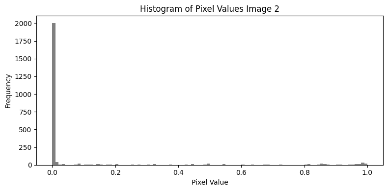

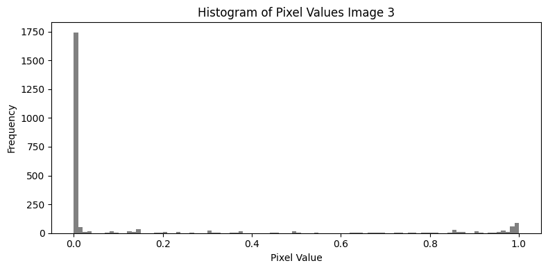

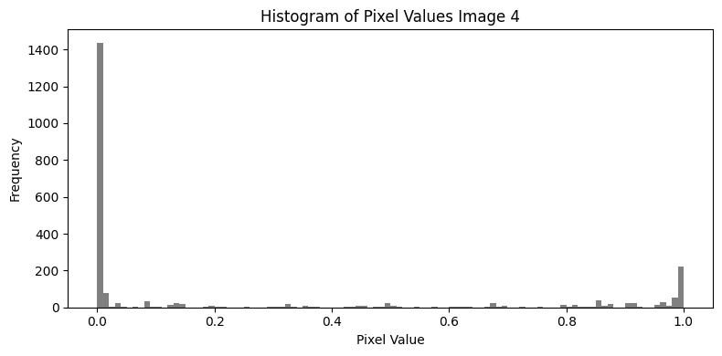

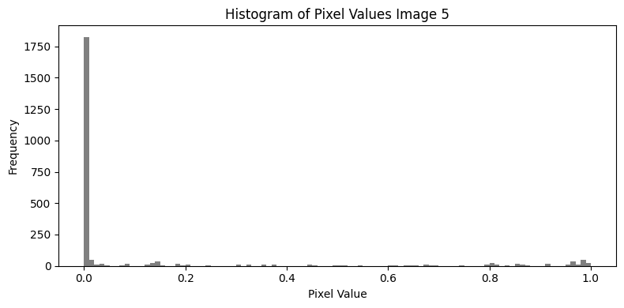

```python
import numpy as np
import matplotlib.pyplot as plt

# Randomly pick a few images
num_images = 5
indices = np.random.choice(len(dataset), num_images, replace=False)


for i, idx in enumerate(indices):
    img_tensor, _ = dataset[idx]
    img_array = img_tensor.squeeze().numpy()

    plt.figure(figsize=(8, 4))
    plt.hist(img_array.flatten(), bins=100, color='gray')
    plt.title(f'Histogram of Pixel Values Image {i + 1}')
    plt.xlabel('Pixel Value')
    plt.ylabel('Frequency')

    plt.tight_layout()
    plt.show()
```

**Description:** Interestingly, all five random images exhibit a very similar histogram shape. Most pixel values are concentrated near 0.0, indicating that the background is predominantly black. A smaller cluster of pixels appears around 1.0, corresponding to the white strokes of the handwritten characters. The remaining pixel values are sparsely distributed in between. This distribution highlights the binary-like nature of the image content, with bright characters on a dark background, which confirms the importance of proper normalisation during preprocessing.

4. Preprocess the dataset (normalize, convert labels, address imbalance if needed).

**Normalize pixel values using dataset-specific mean and standard deviation**

**Normalize the pixel values**

```python
transform = transforms.Compose([
    transforms.ToTensor(),
    transforms.Normalize(mean , std)
])

# Reload the dataset with the updated transform
dataset = datasets.ImageFolder(root=data_dir, transform=transform)
```

**Convert target labels to numerical class indices (torch.LongTensor)**

- This is automatically handled by ImageFolder, which maps each class folder name to a unique integer label.

**Address class imbalance**

- Not needed in this case, as all 36 classes have exactly 2,800 samples. Verified earlier using the class distribution bar chart.
5. Split the dataset into training, validation, and test sets.

```python
from sklearn.model_selection import train_test_split
from torch.utils.data import Subset, DataLoader
import numpy as np

# Get all indices of the dataset
indices = list(range(len(dataset)))
labels = [label for _, label in dataset]

# First split: Train vs (Val + Test)
train_indices, val_test_indices = train_test_split(indices, test_size=0.3, random_state=1227, stratify=labels)

# Split val/test labels for stratification again
val_test_labels = [labels[i] for i in val_test_indices]

# Second split: Val vs Test
val_indices, test_indices = train_test_split(val_test_indices, test_size=0.5,random_state=1227,stratify=val_test_labels)

# Create Subsets for each split
train_dataset = Subset(dataset, train_indices)
val_dataset = Subset(dataset, val_indices)
test_dataset = Subset(dataset, test_indices)

# Dataloaders
batch_size = 64
train_loader = DataLoader(train_dataset, batch_size=batch_size, shuffle=True)
val_loader = DataLoader(val_dataset, batch_size=batch_size, shuffle=False)
test_loader = DataLoader(test_dataset, batch_size=batch_size, shuffle=False)

print(f"Training set size: {len(train_dataset)}")
print(f"Validation set size: {len(val_dataset)}")
print(f"Test set size: {len(test_dataset)}")
```

```
Training set size: 70560
Validation set size: 15120
Test set size: 15120
```

## Step 2: Implementing a basic CNN

1. Design a CNN architecture with ≤ 10 hidden layers for 36-class classification.

```python
import torch
import torch.nn as nn
import torch.nn.functional as F

class MyCNN(nn.Module):
    def __init__(self):
        super(MyCNN, self).__init__()
        #Convolutional Layers to extract features
        self.conv_layers = nn.Sequential(
            # 1st Conv layer
            nn.Conv2d(in_channels=3, out_channels=32, kernel_size=3, padding=1),
            nn.ReLU(),
            nn.MaxPool2d(kernel_size=2, stride=2), # Downsample: 28x28 → 14x14

            #2nd Conv layer
            nn.Conv2d(in_channels=32, out_channels=64, kernel_size=3, padding=1),
            nn.ReLU(),
            nn.MaxPool2d(kernel_size=2, stride=2), # Downsample: 14x14 → 7x7

            # 3rd Conv layer removed after testing — accuracy gains were minimal relative to compute/memory cost.

            # # 3rd Conv layer
            # nn.Conv2d(in_channels=64, out_channels=128, kernel_size=3, padding=1),
            # nn.ReLU(),

            # Dropout
            nn.Dropout(0.25)
        )
        #Fully Connected Layers to classify
        self.fc_layers = nn.Sequential(
            nn.Flatten(),
            nn.Linear(64 * 7 * 7, 128),
            nn.ReLU(),
            nn.Linear(128, 36)
        )

    def forward(self, x):
        x = self.conv_layers(x) # Feature extraction
        x = self.fc_layers(x)   # Classification
        return x
```

2. Display the model summary using `torchinfo.summary` or equivalent.

```python
!pip install torchinfo
```

```
Downloading torchinfo-1.8.0-py3-none-any.whl (23 kB)
```

```python
from torchinfo import summary

model = MyCNN().to(device)
summary(model, input_size=(64, 3, 28, 28))
```

```
==========================================================================================
Layer (type:depth-idx)                   Output Shape              Param #
==========================================================================================
MyCNN                                    [64, 36]                  --
├─Sequential: 1-1                        [64, 64, 7, 7]            --
│    └─Conv2d: 2-1                       [64, 32, 28, 28]          896
│    └─ReLU: 2-2                         [64, 32, 28, 28]          --
│    └─MaxPool2d: 2-3                    [64, 32, 14, 14]          --
│    └─Conv2d: 2-4                       [64, 64, 14, 14]          18,496
│    └─ReLU: 2-5                         [64, 64, 14, 14]          --
│    └─MaxPool2d: 2-6                    [64, 64, 7, 7]            --
│    └─Dropout: 2-7                      [64, 64, 7, 7]            --
├─Sequential: 1-2                        [64, 36]                  --
│    └─Flatten: 2-8                      [64, 3136]                --
│    └─Linear: 2-9                       [64, 128]                 401,536
│    └─ReLU: 2-10                        [64, 128]                 --
│    └─Linear: 2-11                      [64, 36]                  4,644
==========================================================================================
Total params: 425,572
Trainable params: 425,572
Non-trainable params: 0
Total mult-adds (Units.MEGABYTES): 302.97
==========================================================================================
Input size (MB): 0.60
Forward/backward pass size (MB): 19.35
Params size (MB): 1.70
Estimated Total Size (MB): 21.66
==========================================================================================
```

## Step 3: Training and optimization

1. Train the CNN model.

**Define loss function and optimizer**

```python
import torch.optim as optim

criterion = nn.CrossEntropyLoss() # loss function
optimizer = optim.Adam(model.parameters(), lr=0.001) # optimizer
```

**Training loop structure**

```python
# Initialize values
num_epochs = 10
train_losses = []
val_losses = []
train_accuracies = []
val_accuracies = []
```

**Training and Validation Loop**

```python
def train_model(
    model,
    train_loader,
    val_loader,
    criterion,
    optimizer,
    device,
    num_epochs=10,
    model_name=None
):
    model.to(device) # Move the model to GPU or CPU
    # Initialize values
    train_losses, val_losses = [], []
    train_accuracies, val_accuracies = [], []

    for epoch in range(num_epochs):
        # Set model for training (enables dropout)
        model.train()
        total_loss, correct, total = 0.0, 0, 0

        # Training loop
        for images, labels in train_loader:
            images, labels = images.to(device), labels.to(device)

            # Forward pass and loss computation
            optimizer.zero_grad()
            outputs = model(images)
            loss = criterion(outputs, labels)
            loss.backward()
            optimizer.step()

            # Track values
            total_loss += loss.item()
            _, predicted = torch.max(outputs, 1)
            total += labels.size(0)
            correct += (predicted == labels).sum().item()

        # Compute training metrices for each epcoh
        train_loss = total_loss / len(train_loader)
        train_acc = correct / total
        train_losses.append(train_loss)
        train_accuracies.append(train_acc)

        # set model to evaluation moode (disable dropout / no grad)
        model.eval()
        val_loss, correct_val, total_val = 0.0, 0, 0

        # Validation  loop
        with torch.no_grad():
            for images, labels in val_loader:
                images, labels = images.to(device), labels.to(device)
                outputs = model(images)
                loss = criterion(outputs, labels)
                val_loss += loss.item()

                _, predicted = torch.max(outputs, 1)
                total_val += labels.size(0)
                correct_val += (predicted == labels).sum().item()
        # Compute validation metrices for each epoch
        val_loss /= len(val_loader)
        val_acc = correct_val / total_val
        val_losses.append(val_loss)
        val_accuracies.append(val_acc)

        print(f"Epoch [{epoch+1}/{num_epochs}] | "
              f"Train Loss: {train_loss:.4f}, Train Acc: {train_acc:.4f} | "
              f"Val Loss: {val_loss:.4f}, Val Acc: {val_acc:.4f}")

    if model_name:
        torch.save(model.state_dict(), f"{model_name}_model.pt")
        print(f"Model weights are being saved")

    return model, train_losses, val_losses, train_accuracies, val_accuracies
```

Modularized Training Loop

```python
model, train_losses, val_losses, train_accuracies, val_accuracies= train_model(
    model,
    train_loader,
    val_loader,
    criterion,
    optimizer,
    device,
    num_epochs=10,
    model_name="baseline"
)
```

```
Epoch [1/10] | Train Loss: 0.5649, Train Acc: 0.8160 | Val Loss: 0.3304, Val Acc: 0.8802
Epoch [2/10] | Train Loss: 0.3156, Train Acc: 0.8847 | Val Loss: 0.2881, Val Acc: 0.8989
Epoch [3/10] | Train Loss: 0.2700, Train Acc: 0.8981 | Val Loss: 0.2728, Val Acc: 0.9021
Epoch [4/10] | Train Loss: 0.2417, Train Acc: 0.9079 | Val Loss: 0.2732, Val Acc: 0.9038
Epoch [5/10] | Train Loss: 0.2251, Train Acc: 0.9114 | Val Loss: 0.2704, Val Acc: 0.9027
Epoch [6/10] | Train Loss: 0.2068, Train Acc: 0.9176 | Val Loss: 0.2664, Val Acc: 0.9048
Epoch [7/10] | Train Loss: 0.1956, Train Acc: 0.9201 | Val Loss: 0.2878, Val Acc: 0.9032
Epoch [8/10] | Train Loss: 0.1852, Train Acc: 0.9235 | Val Loss: 0.2716, Val Acc: 0.9100
Epoch [9/10] | Train Loss: 0.1785, Train Acc: 0.9262 | Val Loss: 0.2794, Val Acc: 0.9091
Epoch [10/10] | Train Loss: 0.1698, Train Acc: 0.9289 | Val Loss: 0.2903, Val Acc: 0.9082
Model weights are being saved
```

```python
import pickle
import os

def evaluate_model(model, test_loader, criterion, device,
                   train_acc=None, train_loss=None, val_acc=None, val_loss=None,
                   title="Final Evaluation Summary",
                   save_results_as=None):
    # Set model to evaluation  mode (disables dropout)
    model.eval()
    # Initialize tracking variables
    test_loss = 0.0
    correct, total = 0, 0
    all_preds, all_labels = [], []

    # Disable gradient computation for efficiency
    with torch.no_grad():
        for images, labels in test_loader:
            # Move inputs to device (GPU or CPU)
            images, labels = images.to(device), labels.to(device)

            # Forward pass and loss computation
            outputs = model(images)
            loss = criterion(outputs, labels)
            test_loss += loss.item()

            # Compute number of correct predictions
            _, predicted = torch.max(outputs, 1)
            correct += (predicted == labels).sum().item()
            total += labels.size(0)

            #Store predictions and true labels for further analysis
            all_preds.extend(predicted.cpu().numpy())
            all_labels.extend(labels.cpu().numpy())

    # Final averaged test loss and accuracy
    test_loss /= len(test_loader)
    test_acc = correct / total

    # Print summary
    print(f"\n{title}")
    if train_acc is not None:
        print(f"Train Accuracy:    {train_acc[-1]:.4f}")
        print(f"Train Loss:        {train_loss[-1]:.4f}")
    if val_acc is not None:
        print(f"Val Accuracy:      {val_acc[-1]:.4f}")
        print(f"Val Loss:          {val_loss[-1]:.4f}")
    print(f"Test Accuracy:     {test_acc:.4f}")
    print(f"Test Loss:         {test_loss:.4f}")

    # Bundle everything for future analysis
    results_dict = {
        "train_acc": train_acc,
        "train_loss": train_loss,
        "val_acc": val_acc,
        "val_loss": val_loss,
        "test_acc": test_acc,
        "test_loss": test_loss,
        "all_preds": all_preds,
        "all_labels": all_labels
    }
    if save_results_as:
        with open(f"{save_results_as}_results.pkl", "wb") as f:
          pickle.dump(results_dict, f)
        print("Results are being saved.")

    return results_dict
```

Modularized Model Evaluation

```python
# Evaluate the baseline model using the modular function
results = evaluate_model(
    model,                    # Baseline model
    test_loader,              # Standard test loader
    criterion,                # Same loss function
    device,                   # GPU/CPU device
    train_acc=train_accuracies,
    train_loss=train_losses,
    val_acc=val_accuracies,
    val_loss=val_losses,
    title="Final Evaluation Summary – Baseline Model",
    save_results_as="baseline"
)
```

```
Final Evaluation Summary – Baseline Model
Train Accuracy:    0.9289
Train Loss:        0.1698
Val Accuracy:      0.9082
Val Loss:          0.2903
Test Accuracy:     0.9075
Test Loss:         0.2800
Results are being saved.
```

2. Implement at least two improvement methods (dropout, data augmentation, etc.).

Improvement method #1

**Dropout : Already Applied**

**Data augmentation**

```python
from torchvision import transforms

# Augmented training transform
augmented_transform = transforms.Compose([
    transforms.RandomRotation(10),                      # Slight rotation
    transforms.RandomAffine(degrees=0, translate=(0.1, 0.1), scale=(0.9, 1.1)),  # Shear/scale
    transforms.ToTensor(),
    transforms.Normalize(mean, std)  # Same normalization
])

# Validation/test transforms stay the same
test_transform = transforms.Compose([
    transforms.ToTensor(),
    transforms.Normalize(mean, std)
])

# Reload dataset using the new transforms
augmented_dataset = datasets.ImageFolder(root=data_dir, transform=augmented_transform)
test_dataset_fixed = datasets.ImageFolder(root=data_dir, transform=test_transform)

# Use same train/val/test indices from before
train_dataset_aug = Subset(augmented_dataset, train_indices)

train_dataset_fixed = Subset(test_dataset_fixed, train_indices)
val_dataset_fixed = Subset(test_dataset_fixed, val_indices)
test_dataset_fixed = Subset(test_dataset_fixed, test_indices)

# Dataloaders
train_loader_aug = DataLoader(train_dataset_aug, batch_size=64, shuffle=True)
# Dataloader for unaugmented
train_loader_fixed = DataLoader(train_dataset_fixed, batch_size=64, shuffle=True)
val_loader_fixed = DataLoader(val_dataset_fixed, batch_size=64, shuffle=False)
test_loader_fixed = DataLoader(test_dataset_fixed, batch_size=64, shuffle=False)
```

```python
model_aug = MyCNN() # Initialize a fresh instance of the MyCNN model
optimizer_aug = torch.optim.Adam(model_aug.parameters(), lr=0.001) # Setup Optimizer
criterion = nn.CrossEntropyLoss() # Define the loss function

# Train the model using augmented data
model_aug, train_losses_aug, val_losses_aug, train_acc_aug, val_acc_aug = train_model(
    model_aug,
    train_loader_aug,
    val_loader_fixed,
    criterion,
    optimizer_aug,
    device,
    num_epochs=10,
    model_name="augmented"
)
```

```
Epoch [1/10] | Train Loss: 0.8307, Train Acc: 0.7368 | Val Loss: 0.3519, Val Acc: 0.8766
Epoch [2/10] | Train Loss: 0.4490, Train Acc: 0.8430 | Val Loss: 0.2956, Val Acc: 0.8948
Epoch [3/10] | Train Loss: 0.3976, Train Acc: 0.8578 | Val Loss: 0.2866, Val Acc: 0.8903
Epoch [4/10] | Train Loss: 0.3702, Train Acc: 0.8640 | Val Loss: 0.2665, Val Acc: 0.9013
Epoch [5/10] | Train Loss: 0.3522, Train Acc: 0.8728 | Val Loss: 0.2530, Val Acc: 0.9102
Epoch [6/10] | Train Loss: 0.3392, Train Acc: 0.8756 | Val Loss: 0.2768, Val Acc: 0.9010
Epoch [7/10] | Train Loss: 0.3277, Train Acc: 0.8779 | Val Loss: 0.2488, Val Acc: 0.9104
Epoch [8/10] | Train Loss: 0.3186, Train Acc: 0.8807 | Val Loss: 0.2402, Val Acc: 0.9112
Epoch [9/10] | Train Loss: 0.3146, Train Acc: 0.8820 | Val Loss: 0.2447, Val Acc: 0.9059
Epoch [10/10] | Train Loss: 0.3034, Train Acc: 0.8854 | Val Loss: 0.2369, Val Acc: 0.9115
Model weights are being saved
```

```python
# Run modular evaluation
results = evaluate_model(
    model_aug,
    test_loader_fixed,
    criterion,
    device,
    train_acc=train_acc_aug,
    train_loss=train_losses_aug,
    val_acc=val_acc_aug,
    val_loss=val_losses_aug,
    title="Final Evaluation Summary - Augmented Model",
    save_results_as="augmented"
)
```

```
Final Evaluation Summary - Augmented Model
Train Accuracy:    0.8854
Train Loss:        0.3034
Val Accuracy:      0.9115
Val Loss:          0.2369
Test Accuracy:     0.9112
Test Loss:         0.2394
Results are being saved.
```

Improvement method #2

Weight regularization (L2)

```python
# Define a fresh model instance for L2 regularization experiment
model_l2 = MyCNN()

# Use Adam optimizer with L2 weight regularization (weight_decay)
optimizer_l2 = torch.optim.Adam(model_l2.parameters(), lr=0.001, weight_decay=1e-4)

# Same loss function
criterion = nn.CrossEntropyLoss()

# Train the L2-regularized model on the original (non-augmented) dataset
model_l2, train_losses_l2, val_losses_l2, train_acc_l2, val_acc_l2 = train_model(
    model_l2,
    train_loader_fixed,
    val_loader_fixed,
    criterion,
    optimizer_l2,
    device,
    num_epochs=10,
    model_name="l2_regularized"
)
```

```
Epoch [1/10] | Train Loss: 0.5656, Train Acc: 0.8167 | Val Loss: 0.3603, Val Acc: 0.8769
Epoch [2/10] | Train Loss: 0.3128, Train Acc: 0.8856 | Val Loss: 0.2954, Val Acc: 0.8944
Epoch [3/10] | Train Loss: 0.2674, Train Acc: 0.8994 | Val Loss: 0.2886, Val Acc: 0.8946
Epoch [4/10] | Train Loss: 0.2425, Train Acc: 0.9061 | Val Loss: 0.2742, Val Acc: 0.9024
Epoch [5/10] | Train Loss: 0.2252, Train Acc: 0.9119 | Val Loss: 0.2732, Val Acc: 0.9029
Epoch [6/10] | Train Loss: 0.2104, Train Acc: 0.9161 | Val Loss: 0.2731, Val Acc: 0.9042
Epoch [7/10] | Train Loss: 0.2015, Train Acc: 0.9181 | Val Loss: 0.2588, Val Acc: 0.9089
Epoch [8/10] | Train Loss: 0.1917, Train Acc: 0.9207 | Val Loss: 0.2784, Val Acc: 0.9073
Epoch [9/10] | Train Loss: 0.1871, Train Acc: 0.9238 | Val Loss: 0.2704, Val Acc: 0.9050
Epoch [10/10] | Train Loss: 0.1817, Train Acc: 0.9249 | Val Loss: 0.2698, Val Acc: 0.9101
Model weights are being saved
```

```python
# Evaluate the L2-regularized model using the reusable function
results = evaluate_model(
    model_l2,
    test_loader_fixed,
    criterion,
    device,
    train_acc=train_acc_l2,
    train_loss=train_losses_l2,
    val_acc=val_acc_l2,
    val_loss=val_losses_l2,
    title="Final Evaluation Summary – L2 Regularized Model",
    save_results_as="l2_regularized"
)
```

```
Final Evaluation Summary – L2 Regularized Model
Train Accuracy:    0.9249
Train Loss:        0.1817
Val Accuracy:      0.9101
Val Loss:          0.2698
Test Accuracy:     0.9133
Test Loss:         0.2582
Results are being saved.
```

3. Compare results using two different optimizers.

**SGD with momentum**

```python
# Re-initialize model from scratch
model_sgd = MyCNN()

# SGD with momentum (standard)
optimizer_sgd = torch.optim.SGD(model_sgd.parameters(), lr=0.001, momentum=0.9)

# Train the model
model_sgd, train_losses_sgd, val_losses_sgd, train_acc_sgd, val_acc_sgd = train_model(
    model_sgd,
    train_loader_fixed,
    val_loader_fixed,
    criterion,
    optimizer_sgd,
    device,
    num_epochs=10,
    model_name="sgd_momentum"
)
```

```
Epoch [1/10] | Train Loss: 1.5073, Train Acc: 0.5694 | Val Loss: 0.6803, Val Acc: 0.7840
Epoch [2/10] | Train Loss: 0.5815, Train Acc: 0.8091 | Val Loss: 0.4424, Val Acc: 0.8553
Epoch [3/10] | Train Loss: 0.4348, Train Acc: 0.8516 | Val Loss: 0.3799, Val Acc: 0.8699
Epoch [4/10] | Train Loss: 0.3759, Train Acc: 0.8666 | Val Loss: 0.3415, Val Acc: 0.8847
Epoch [5/10] | Train Loss: 0.3408, Train Acc: 0.8785 | Val Loss: 0.3242, Val Acc: 0.8917
Epoch [6/10] | Train Loss: 0.3163, Train Acc: 0.8848 | Val Loss: 0.3225, Val Acc: 0.8878
Epoch [7/10] | Train Loss: 0.2966, Train Acc: 0.8930 | Val Loss: 0.3087, Val Acc: 0.8917
Epoch [8/10] | Train Loss: 0.2849, Train Acc: 0.8958 | Val Loss: 0.3061, Val Acc: 0.8924
Epoch [9/10] | Train Loss: 0.2715, Train Acc: 0.8986 | Val Loss: 0.3003, Val Acc: 0.8954
Epoch [10/10] | Train Loss: 0.2603, Train Acc: 0.9026 | Val Loss: 0.2936, Val Acc: 0.8989
Model weights are being saved
```

**AdamW with weight_decay**

```python
# Re-initialize model from scratch
model_adamw = MyCNN()

# AdamW optimizer (recommended over Adam when using weight decay)
optimizer_adamw = torch.optim.AdamW(model_adamw.parameters(), lr=0.001, weight_decay=1e-4)

# Train the model
model_adamw, train_losses_adamw, val_losses_adamw, train_acc_adamw, val_acc_adamw = train_model(
    model_adamw,
    train_loader_fixed,
    val_loader_fixed,
    criterion,
    optimizer_adamw,
    device,
    num_epochs=10,
    model_name="adamw"
)
```

```
Epoch [1/10] | Train Loss: 0.5668, Train Acc: 0.8149 | Val Loss: 0.3293, Val Acc: 0.8864
Epoch [2/10] | Train Loss: 0.3127, Train Acc: 0.8870 | Val Loss: 0.2848, Val Acc: 0.9003
Epoch [3/10] | Train Loss: 0.2672, Train Acc: 0.8992 | Val Loss: 0.2743, Val Acc: 0.9030
Epoch [4/10] | Train Loss: 0.2414, Train Acc: 0.9069 | Val Loss: 0.2629, Val Acc: 0.9083
Epoch [5/10] | Train Loss: 0.2196, Train Acc: 0.9132 | Val Loss: 0.2698, Val Acc: 0.9059
Epoch [6/10] | Train Loss: 0.2087, Train Acc: 0.9165 | Val Loss: 0.2755, Val Acc: 0.9060
Epoch [7/10] | Train Loss: 0.1926, Train Acc: 0.9208 | Val Loss: 0.2878, Val Acc: 0.9025
Epoch [8/10] | Train Loss: 0.1850, Train Acc: 0.9244 | Val Loss: 0.2786, Val Acc: 0.9034
Epoch [9/10] | Train Loss: 0.1754, Train Acc: 0.9267 | Val Loss: 0.2910, Val Acc: 0.9030
Epoch [10/10] | Train Loss: 0.1691, Train Acc: 0.9296 | Val Loss: 0.2833, Val Acc: 0.9015
Model weights are being saved
```

**Evaluating both optimizers**

```python
# For SGD
results = evaluate_model(
    model_sgd,
    test_loader_fixed,
    criterion,
    device,
    train_acc=train_acc_sgd,
    train_loss=train_losses_sgd,
    val_acc=val_acc_sgd,
    val_loss=val_losses_sgd,
    title="Final Evaluation Summary – SGD Optimizer",
    save_results_as="sgd_momentum"
)

# For AdamW
results = evaluate_model(
    model_adamw,
    test_loader_fixed,
    criterion,
    device,
    train_acc=train_acc_adamw,
    train_loss=train_losses_adamw,
    val_acc=val_acc_adamw,
    val_loss=val_losses_adamw,
    title="Final Evaluation Summary – AdamW Optimizer",
    save_results_as="adamw"
)
```

```
Final Evaluation Summary – SGD Optimizer
Train Accuracy:    0.9026
Train Loss:        0.2603
Val Accuracy:      0.8989
Val Loss:          0.2936
Test Accuracy:     0.8966
Test Loss:         0.2936
Results are being saved.

Final Evaluation Summary – AdamW Optimizer
Train Accuracy:    0.9296
Train Loss:        0.1691
Val Accuracy:      0.9015
Val Loss:          0.2833
Test Accuracy:     0.9035
Test Loss:         0.2757
Results are being saved.
```

4. Discuss optimizer performance and effect of training improvements.

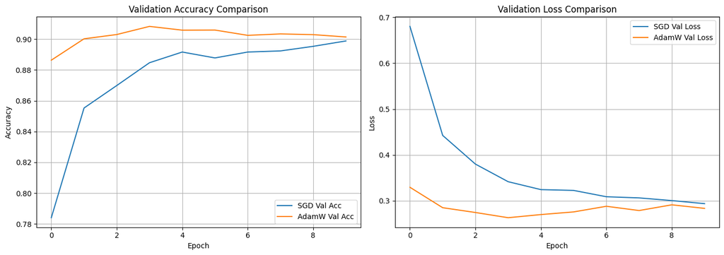

```python
import pickle
import matplotlib.pyplot as plt

# Load results
with open("sgd_momentum_results.pkl", "rb") as f:
    sgd = pickle.load(f)

with open("adamw_results.pkl", "rb") as f:
    adamw = pickle.load(f)

# Set up side-by-side subplots
plt.figure(figsize=(14, 5))

# Subplot 1: Validation Accuracy
plt.subplot(1, 2, 1)
plt.plot(sgd["val_acc"], label="SGD Val Acc")
plt.plot(adamw["val_acc"], label="AdamW Val Acc")
plt.title("Validation Accuracy Comparison")
plt.xlabel("Epoch")
plt.ylabel("Accuracy")
plt.legend()
plt.grid(True)

# Subplot 2: Validation Loss
plt.subplot(1, 2, 2)
plt.plot(sgd["val_loss"], label="SGD Val Loss")
plt.plot(adamw["val_loss"], label="AdamW Val Loss")
plt.title("Validation Loss Comparison")
plt.xlabel("Epoch")
plt.ylabel("Loss")
plt.legend()
plt.grid(True)

plt.tight_layout()
plt.show()
```

Between SGD with momentum and AdamW with weight decay; AdamW demonstrated slightly superior performance. It achieved higher final train (0.9296), validation (0.9015), and test accuracy (0.9035) compared to SGD’s corresponding scores of 0.9026, 0.8989, and 0.8966.

While SGD improved steadily across epochs and remained competitive, its slower convergence and higher loss suggest it may benefit from further tuning (e.g., learning rate decay or extended training). Overall, optimization tools like weight decay and adaptive step sizes in AdamW had a measurable impact on training stability and final performance.

5. Save the best-performing model weights.

```python
# Save the best model (L2 Regularized)
torch.save(model_l2.state_dict(), "best_model_weights.pt")
print("Best-performing model weights saved as best_model_weights.pt")
```

```
Best-performing model weights saved as best_model_weights.pt
```

## Step 4: Evaluation and analysis

1. Report training/validation/testing metrics and analyze the results

```python
import pickle

with open("l2_regularized_results.pkl", "rb") as f:
    results = pickle.load(f)

print("Final Evaluation Summary - L2 Regularized Model")
print(f"Train Accuracy: {results['train_acc'][-1]:.4f}")
print(f"Train Loss:     {results['train_loss'][-1]:.4f}")
print(f"Val Accuracy:   {results['val_acc'][-1]:.4f}")
print(f"Val Loss:       {results['val_loss'][-1]:.4f}")
print(f"Test Accuracy:  {results['test_acc']:.4f}")
print(f"Test Loss:      {results['test_loss']:.4f}")
```

```
Final Evaluation Summary - L2 Regularized Model
Train Accuracy: 0.9249
Train Loss:     0.1817
Val Accuracy:   0.9101
Val Loss:       0.2698
Test Accuracy:  0.9133
Test Loss:      0.2582
```

The L2 Regularized model demonstrates strong generalization and performance across all datasets:

- The training accuracy is high (92.49%) with a low training loss (0.18), indicating the model fit the training data well.
- Validation accuracy (91.01%) and test accuracy (91.33%) closely match training accuracy, suggesting minimal overfitting.
- Loss values remain low and consistent across validation and test sets, reflecting stable convergence.

This suggests that regularization helped the model learn more robust, generalizable features, especially useful in image classification tasks where input variation improves model resilience.

2. Plot accuracy and loss over epochs.

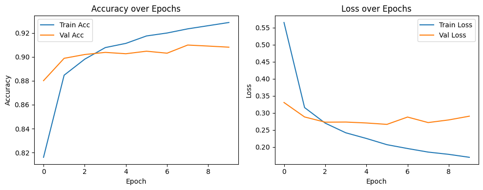

```python
import matplotlib.pyplot as plt

# Assume you already have train_accuracies and val_accuracies in memory
plt.figure(figsize=(10, 4))
plt.subplot(1, 2, 1)
plt.plot(train_accuracies, label='Train Acc')
plt.plot(val_accuracies, label='Val Acc')
plt.title("Accuracy over Epochs")
plt.xlabel("Epoch")
plt.ylabel("Accuracy")
plt.legend()

plt.subplot(1, 2, 2)
plt.plot(train_losses, label='Train Loss')
plt.plot(val_losses, label='Val Loss')
plt.title("Loss over Epochs")
plt.xlabel("Epoch")
plt.ylabel("Loss")
plt.legend()
plt.tight_layout()
plt.show()
```

3. Generate and analyze confusion matrix.

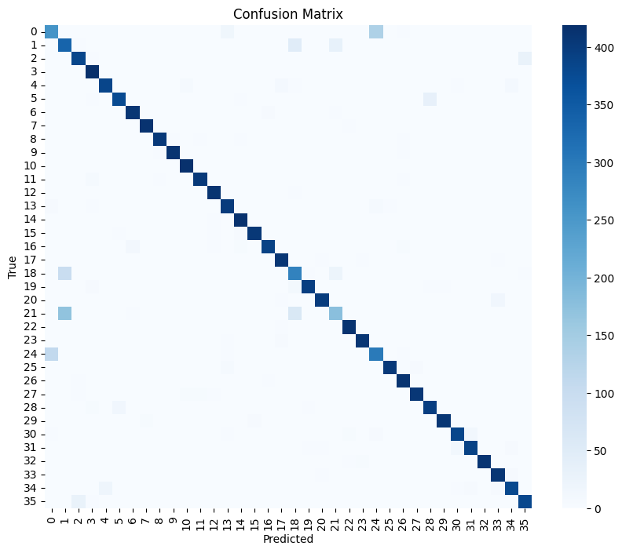

```python
from sklearn.metrics import confusion_matrix
import seaborn as sns
import numpy as np

cm = confusion_matrix(results["all_labels"], results["all_preds"])
plt.figure(figsize=(10, 8))
sns.heatmap(cm, cmap="Blues", fmt='d')
plt.title("Confusion Matrix")
plt.xlabel("Predicted")
plt.ylabel("True")
plt.show()
```

The confusion matrix indicates high overall classification accuracy, but a few specific misclassifications stand out. For example, actual class 24 is often confused as class 0, and vice versa. Similarly, classes 21 and 18 are sometimes predicted as class 1. These errors likely reflect visual similarity between certain alphanumeric characters (e.g., 'O' and '0', 'I' and '1'), which is common in handwritten or noisy character datasets. Despite these cases, the overall structure remains strongly diagonal, indicating robust model performance.

4. Compute and analyze precision, recall, F1 scores.

```python
from sklearn.metrics import precision_recall_fscore_support

precision, recall, f1, _ = precision_recall_fscore_support(
    results["all_labels"], results["all_preds"], average='macro'
)

print(f"Precision: {precision:.4f}")
print(f"Recall:    {recall:.4f}")
print(f"F1 Score:  {f1:.4f}")
```

```
Precision: 0.9157
Recall:    0.9133
F1 Score:  0.9124
```

These metrics help assess the model's ability to correctly identify each class while minimizing false positives and false negatives.